# Part II - (Electric Load and Weather in Texas State)

## Investigation Overview

The main goal of this investigation is to view insights showing how weather affects the consumption and generation of electrical energy.

## Dataset Overview

The dataset contains load and weather data for different regions in Texas in the United States.

```python
# import all packages and set plots to be embedded inline
import numpy as np
import pandas as pd
import matplotlib.pyplot as plt
import seaborn as sns
import matplotlib
matplotlib.rcParams["figure.dpi"] = 300
matplotlib.rcParams['savefig.dpi'] = 300
#%matplotlib inline

# suppress warnings from final output
import warnings
warnings.simplefilter("ignore")
```

```python
# Load the datasets used in the visualizations
df_Total_Energy = pd.read_csv('Total_Wind_Energy.csv')
df_Houston_Corr = pd.read_csv('Houston_Corr.csv')
df_Houston = pd.read_csv('Houston.csv')
```

## Best City for Wind Power Investments

The penetration of Renewable Energy Resources (RES) is rapidly increasing in power grids in recent years globally. The most common RES are wind power systems and solar photovoltaic systems. These systems depend mainly on weather conditions. For example, for wind energy, the higher the wind speed is, the higher the wind turbine output power will be. Therefore, before installing wind turbines in a particular location, we need to make sure that this location has a good "wind speed" profile. For this reason, we calculated the output power using wind speed for three cities in Texas which are San Antonio, Dallas, and Houston to see which city is best for wind power investments. As we can see from the bar chart below, "Dallas" is the best out of the three cities for wind power investments.

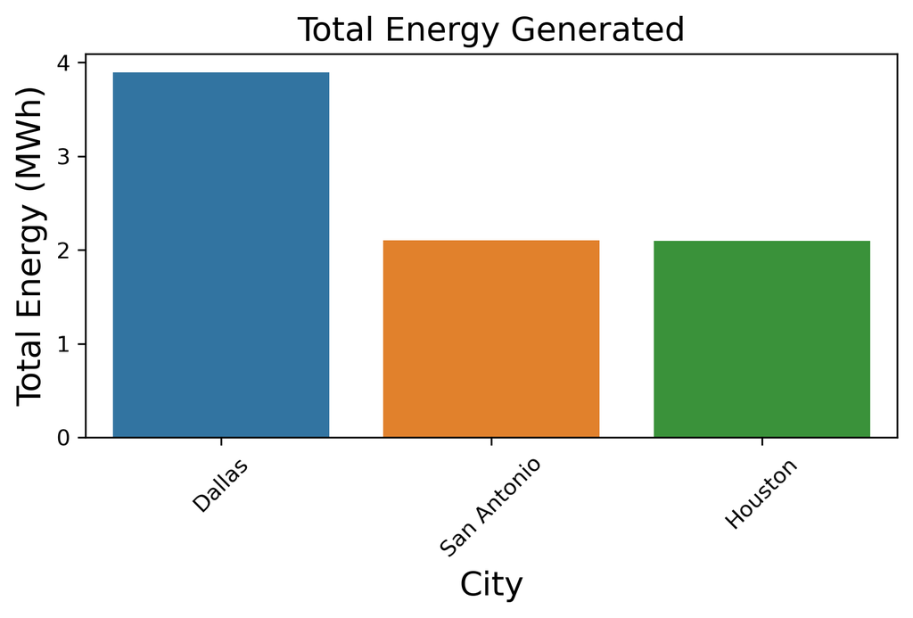

```python
def plot_bar_chart(df,x_axis_label,y_axis_label, gen):
    sns.barplot(x=x_axis_label, y=y_axis_label,data=df)
    plt.xticks(rotation = 45)
    plt.title("Total Energy "+ gen,fontsize=15)
    plt.xlabel(x_axis_label,fontsize=15)
    plt.ylabel("Total Energy (MWh)",fontsize= 15)
    plt.tight_layout()
    plt.show()

plot_bar_chart(df_Total_Energy, 'City', 'Total Energy', 'Generated')
```

## Most Influential Meteorological Factor On Electric Demand

When developing electric demand forecasting models, we need to know the most influential factors to get good results. One way to determine whether a certain factor can be used as a predictor for a certain variable is by calculating the Pearson correlation coefficient. Therefore, we have calculated the absolute value for the correlation coefficient for different metrological factors such as temperature, wind speed, and humidity to see which factor has the highest correlation. Results show that "Temperature" is the most influential factor.

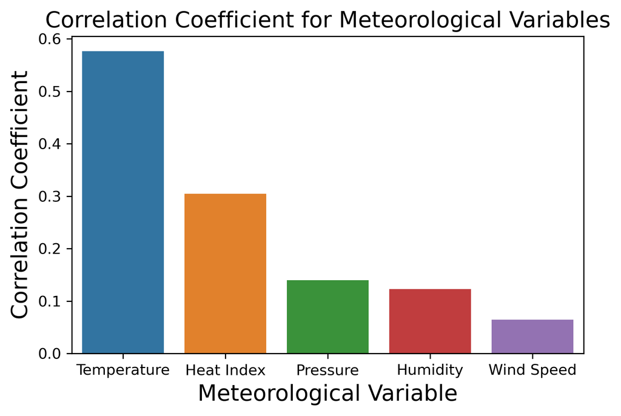

```python
sns.barplot(x='Meteorological Variable', y='Correlation Coefficient',data=df_Houston_Corr)
plt.xticks()
plt.title("Correlation Coefficient for Meteorological Variables",fontsize=15)
plt.xlabel("Meteorological Variable",fontsize=15)
plt.ylabel("Correlation Coefficient",fontsize= 15)
plt.tight_layout()
plt.show()
```

## Variation of Load and Temperature over Time

Analyzing how load varies with time can help power system operators predict future electricity demand. The forecast can help power companies satisfy future electricity needs. So, they will know the amount of power they need to generate and purchase from other sources. Also, it will help them know the future supply needs of fuel and other inputs. We can see from the figure below that the demand increases in summer due to the increased use of air conditioning load. Therefore, power companies will have to turn on more generators in the summer. Consequently, they need to purchase more fuel, and so on. Also, it is important to maintain power equipment more in the summer. Heat can cause more wear and tear on the power equipment so cooling and lubrication should be monitored more closely during the summer months.

[figure not shown]

```python
# Create figure and axis objects
fig,ax = plt.subplots()
Window_Size = 240

# Make the plot
ax.plot(df_Houston.datetime,
       (df_Houston.Temperature-273.15).rolling(Window_Size).mean().tolist(),
        color="red",
        #marker="o"
       )
# Set x-axis and y-axis labels
ax.set_xlabel("Time", fontsize = 14)
ax.set_ylabel("Temperature (°C)",color="red",fontsize=14)

# Create a second object, i.e., twin object, for the other y-axis on the plot

ax2=ax.twinx()

# Make the plot with the second y-axis using the second axis object
ax2.plot(df_Houston.datetime, df_Houston.COAST.rolling(Window_Size).mean().tolist(),color="blue")
ax2.set_ylabel("Load (MW)",color="blue",fontsize=14)
plt.show()
```

```python
!jupyter nbconvert Part_II_slide_deck.ipynb --to slides --post serve --no-input --no-prompt --ServePostProcessor.port=8903
```

```
^C
```